# Regression model - Motor trend

Goga

2023-06-13

# Executive Summary

Our work for Motor Trend, a magazine about the automobile industry. Looking at a data set of a collection of cars, they are interested in exploring the relationship between a set of variables and miles per gallon (MPG) (outcome). They are particularly interested in the following two questions:

- “Is an automatic or manual transmission better for MPG”
- “Quantify the MPG difference between automatic and manual transmissions”

# Exploratory data analysis

```r
library("ggplot2")
library(GGally)
library("gridExtra")
library("dplyr")
# Load data
data(mtcars)
```

## Compute summary statistics of data subsets:

First, let’s check the average.

```r
aggregate(mpg ~ factor(am, labels = c("AT", "MT")), mtcars, mean)
```

```
##   factor(am, labels = c("AT", "MT"))      mpg
## 1                                 AT 17.14737
## 2                                 MT 24.39231
```

The MT car seems to have a higher MPG.

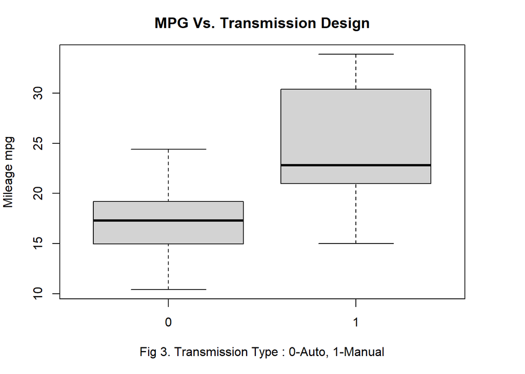

```r
par(mar=c(5,4,3,4))
boxplot(mpg~am,data=mtcars,xlab="Fig 3. Transmission Type : 0-Auto, 1-Manual",ylab="Mileage mpg",
        main="MPG Vs. Transmission Design")
```

Here we see the boxplot that proves the average calculations for automatic and manual MPG.

## Calculate correlation:

Calculate the correlation to see the relationship with other elements.

```r
round(cor(mtcars), 2)[1, ]
```

```
##   mpg   cyl  disp    hp  drat    wt  qsec    vs    am  gear  carb
##  1.00 -0.85 -0.85 -0.78  0.68 -0.87  0.42  0.66  0.60  0.48 -0.55
```

`wt`, `disp`, `cyl` and `hp` show high correlation.

## Fit Multiple Regression Models

```r
fit1 <- lm(mpg ~ am, mtcars)
fit2 <- lm(mpg ~ am + wt, mtcars)
fit3 <- lm(mpg ~ am + wt + disp, mtcars)
fit4 <- lm(mpg ~ am + wt + disp + cyl, mtcars)
fit5 <- lm(mpg ~ am + wt + disp + cyl + hp, mtcars)
```

```r
anova(fit1, fit2, fit3, fit4, fit5)
```

```
## Analysis of Variance Table
##
## Model 1: mpg ~ am
## Model 2: mpg ~ am + wt
## Model 3: mpg ~ am + wt + disp
## Model 4: mpg ~ am + wt + disp + cyl
## Model 5: mpg ~ am + wt + disp + cyl + hp
##   Res.Df    RSS Df Sum of Sq       F    Pr(>F)
## 1     30 720.90
## 2     29 278.32  1    442.58 70.5432 7.017e-09 ***
## 3     28 246.56  1     31.76  5.0628  0.033130 *
## 4     27 188.43  1     58.13  9.2655  0.005289 **
## 5     26 163.12  1     25.31  4.0336  0.055097 .
## ---
## Signif. codes:  0 '***' 0.001 '**' 0.01 '*' 0.05 '.' 0.1 ' ' 1
```

```r
betterFit <- fit4
summary(betterFit)
```

```
##
## Call:
## lm(formula = mpg ~ am + wt + disp + cyl, data = mtcars)
##
## Residuals:
##    Min     1Q Median     3Q    Max
## -4.318 -1.362 -0.479  1.354  6.059
##
## Coefficients:
##              Estimate Std. Error t value Pr(>|t|)
## (Intercept) 40.898313   3.601540  11.356 8.68e-12 ***
## am           0.129066   1.321512   0.098  0.92292
## wt          -3.583425   1.186504  -3.020  0.00547 **
## disp         0.007404   0.012081   0.613  0.54509
## cyl         -1.784173   0.618192  -2.886  0.00758 **
## ---
## Signif. codes:  0 '***' 0.001 '**' 0.01 '*' 0.05 '.' 0.1 ' ' 1
##
## Residual standard error: 2.642 on 27 degrees of freedom
## Multiple R-squared:  0.8327, Adjusted R-squared:  0.8079
## F-statistic: 33.59 on 4 and 27 DF,  p-value: 4.038e-10
```

This Multivariable Regression test now gives us an R-squared value of over .83, suggesting that 83% or more of variance can be explained by the multivariable model. P-values for `cyl` and `wt` are below 5%, suggesting that these are confounding variables in the relation between car Transmission and MPG.

## Residual and Diagnostics

# Appendix

## Figure 1

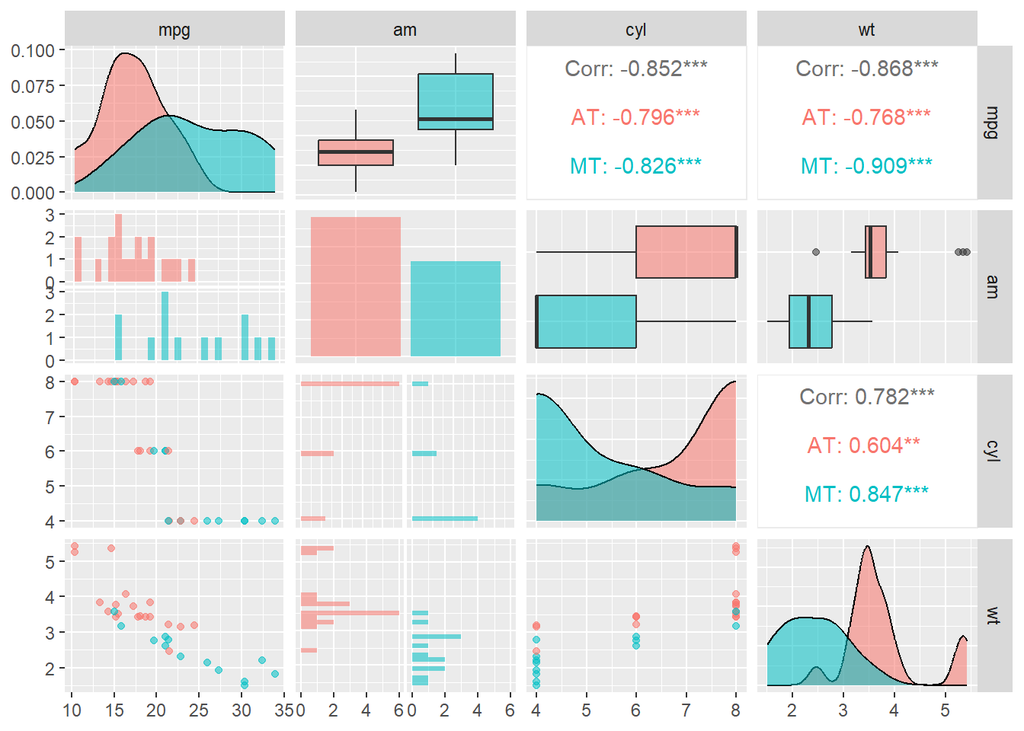

```r
# Factorize
mtcars$am <- factor(mtcars$am, labels = c("AT", "MT"))
ggpairs(mtcars[, c(1, 9, 2, 6)], aes(color = am, alpha = .4))
```

## Figure 2

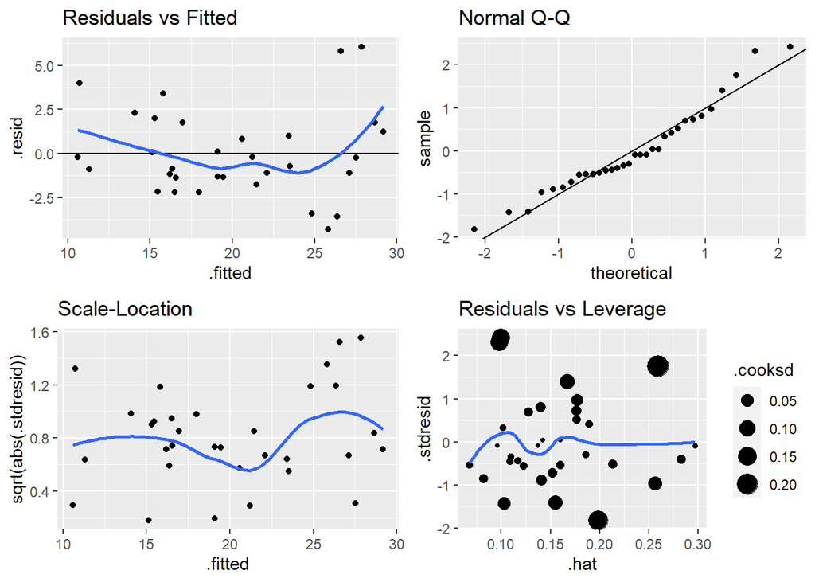

```r
# Residuals vs Fitted
plot1 <- ggplot(betterFit, aes(.fitted, .resid)) +
        geom_point() +
        geom_hline(yintercept = 0) +
        geom_smooth(se = FALSE) +
        ggtitle("Residuals vs Fitted")
# Normal Q-Q
plot2 <- ggplot(betterFit) +
        stat_qq(aes(sample = .stdresid)) +
        geom_abline() +
        ggtitle("Normal Q-Q")
# Scale-Location
plot3 <- ggplot(betterFit, aes(.fitted, sqrt(abs(.stdresid)))) +
        geom_point() +
        geom_smooth(se = FALSE) +
        ggtitle("Scale-Location")
# Standardized Residuals vs Leverage
plot4 <- ggplot(betterFit, aes(.hat, .stdresid)) +
        geom_point(aes(size = .cooksd)) +
        geom_smooth(se = FALSE) +
        ggtitle("Residuals vs Leverage")

grid.arrange(plot1, plot2, plot3, plot4, ncol = 2)
```